# intestigating the linear relationship between motifs and gene expression level

Hanqin Du

2019/10/13

# prepare data

### Load library and function

Load library for data frame organization, training linear model and plotting

### Load Data

Load 69 published motifs (from Abhi’s report) and 3’UTR sequences of 4388 different genes. Then, Load Gasch’s gene-expression-level data which describes the relative gene expression level under 173 different environment conditions among 6152 genes.

**a problem with Gasch’s data: there are three duplicated column called ‘hs_00min_hs-2’, need to check them in the article**

### Construct Motif Frequencies Matrix from 3’UTR Ref sequences

By converting all the motifs to regular expression, we are able to construct motifs frequency matrix which describes the frequency of 69 motifs among 4388 different genes.

### Merge motif frequency matrix with Gasch’s data

Finally, we inner join the motif frequency matrix with Gasch’s data and get the data frame we are going to explore. Each row represented data from one of the 4284 genes (since we have carried out inner join, only the genes shown in both tables are kept). There are 245 columns in total. 3 of them describe the basic information (short and formal name) of the gene represented by the row. 173 of them show how the gene expression level change under the certain environment condition and the other 69 of them respect the frequency of the 69 published motifs on the 3’UTR.

# Investigate motif frequency

### Summing the frequency of each motif

To begin with, we want to investigate the sample size of the data. After summing by columns, we get the total frequency of each motif among all the 4284 genes. The mean is 141 while the median is merely 5, which indicates more than half of the motifs have a very low frequency. It could be difficult to carry out analysis on these low-frequency motifs since a small sample size could led to high uncertainty.

summary of the summing frequency:

```
##    Min. 1st Qu.  Median    Mean 3rd Qu.    Max.
##       0       0       5     141      80    1417
```

### Drawing histogram:

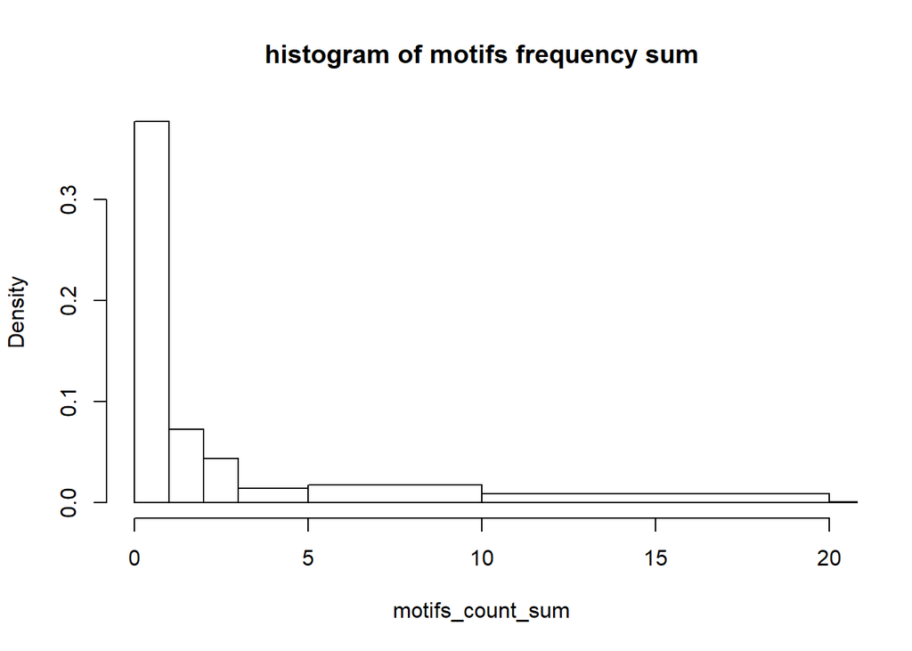

```r
hist(motifs_count_sum, xlim = c(0,20), breaks = c(0,1,2,3,5,10,20,50,3000), main = 'histogram of motifs frequency sum')
```

### Draw the table:

| Frequency | number of motifs (n) |
| --- | --- |
| n = 0 | 19 |
| 0 < n < 6 | 17 |
| 5 < n < 21 | 12 |
| n > 20 | 21 |

One possible explanation of the huge amount of low-frequency motifs is that it is hard to match exactly the regular expression to the UTR sequence. Another point is, a motif with a significant effect on regulation is reasonable to have a small frequency.

### Remove motifs with frequency 0

There is no way to study motifs with 0 frequency as their correlation coefficient against the expression level should always be 0. Therefore, simply removing them should be reasonable.

# Compute correlation coefficient between motifs and expression level

To check if expression level depends linearly on some of the motifs, the easiest way is to compute the correlation coefficient between them.

### Picking a group of heat-shock related environment condition

We start by picking a group of environmental conditions about heat shock - Heat Shock from Various Temperatures to 37°C. According to Gasch’s article:

> Six cultures were grown continuously at 17°, 21°, 25°, 29°, 33°, or 37°C for ;20 h. Half of each culture was collected to serve as the unstressed reference, and the remainder of each culture was collected by centrifugation and immediately resuspended in 37°C medium. After 20 min at 37°C, the cells were harvested, and total RNA was isolated.

Therefore, the figure of the expression level represents how the cell response to the heat shock. A positive number shows the expression level is raised while a negative number means decreasing.

```r
names_temperature_condition = vector(mode="character", length=5)
names_temperature_condition[1] = "hs_17to37_20min"
names_temperature_condition[2] = "hs_21to37_20min"
names_temperature_condition[3] = "hs_25to37_20min"
names_temperature_condition[4] = "hs_29to37_20min"
names_temperature_condition[5] = "hs_33to37_20min"
```

```r
summary(fullTable_Gasch[names_temperature_condition])
```

```
##  hs_17to37_20min    hs_21to37_20min    hs_25to37_20min
##  Min.   :-5.64000   Min.   :-5.06000   Min.   :-5.06000
##  1st Qu.:-0.69000   1st Qu.:-0.63000   1st Qu.:-0.62000
##  Median : 0.03000   Median : 0.03000   Median : 0.06000
##  Mean   :-0.03226   Mean   :-0.04806   Mean   :-0.02422
##  3rd Qu.: 0.72000   3rd Qu.: 0.63000   3rd Qu.: 0.69000
##  Max.   : 6.99000   Max.   : 7.08000   Max.   : 6.64000
##  NA's   :48         NA's   :53         NA's   :33
##  hs_29to37_20min    hs_33to37_20min
##  Min.   :-4.64000   Min.   :-4.06000
##  1st Qu.:-0.56000   1st Qu.:-0.43000
##  Median : 0.00000   Median : 0.03000
##  Mean   :-0.03016   Mean   : 0.02182
##  3rd Qu.: 0.54000   3rd Qu.: 0.46000
##  Max.   : 6.44000   Max.   : 5.31000
##  NA's   :41         NA's   :33
```

### Calculate the correlation coefficient

At this step, we get a data frame that each row represent the correlation coefficients of a motif under these environmental conditions

a peek of the dataset:

```r
head(motif_overview)
```

```
##                hs_17to37_20min hs_21to37_20min hs_25to37_20min
## ATATTC             0.080815697     0.081057510     0.093458982
## TGCAT              0.013098901     0.023072505     0.023603863
## TGTAAATA           0.045962713     0.045653364     0.049618252
## TTTTTTA            0.006132755     0.003651708     0.007260377
## CHUGUAWAUAWAWA     0.005609829     0.012752365     0.017380781
## UGUAHMNUA         -0.231352901    -0.219857177    -0.221008346
##                hs_29to37_20min hs_33to37_20min      R_mean
## ATATTC              0.09883912     0.095912755  0.09001681
## TGCAT               0.02091618     0.004054877  0.01694926
## TGTAAATA            0.05748263     0.077473077  0.05523801
## TTTTTTA             0.01848922     0.022725652  0.01165194
## CHUGUAWAUAWAWA      0.01775529     0.027182571  0.01613617
## UGUAHMNUA          -0.21107196    -0.164773363 -0.20961275
```

```r
summary(motif_overview)
```

```
##  hs_17to37_20min     hs_21to37_20min     hs_25to37_20min
##  Min.   :-0.231353   Min.   :-0.219857   Min.   :-0.221008
##  1st Qu.:-0.016248   1st Qu.:-0.016435   1st Qu.:-0.017540
##  Median :-0.001453   Median :-0.005949   Median :-0.006208
##  Mean   :-0.008835   Mean   :-0.008125   Mean   :-0.007351
##  3rd Qu.: 0.007945   3rd Qu.: 0.012973   3rd Qu.: 0.015618
##  Max.   : 0.080816   Max.   : 0.081058   Max.   : 0.093459
##  hs_29to37_20min     hs_33to37_20min         R_mean
##  Min.   :-0.211072   Min.   :-0.164773   Min.   :-0.209613
##  1st Qu.:-0.018287   1st Qu.:-0.014905   1st Qu.:-0.016422
##  Median :-0.002180   Median :-0.004070   Median :-0.005256
##  Mean   :-0.006317   Mean   :-0.004382   Mean   :-0.007002
##  3rd Qu.: 0.015438   3rd Qu.: 0.010034   3rd Qu.: 0.011279
##  Max.   : 0.098839   Max.   : 0.095913   Max.   : 0.090017
```

### Plot coefficient of each motif against each heat-shock related environment condition

There are four motifs show a much higher correlation coefficient rather than the others, which, indicate the linear relationship between these motifs and expression level. One point worth mentioning is that all these motifs are also focused by Abhi where `TGTATAWT` is explained to be positively associated with RNA stability and the rest three of them are explained to be negatively associated with the RNA stability. However, Abhi is not quite confident with the conclusion of `UGUAHMNUA` as the negative relationship can only be derived from Chan’s data but not Sun’s data.

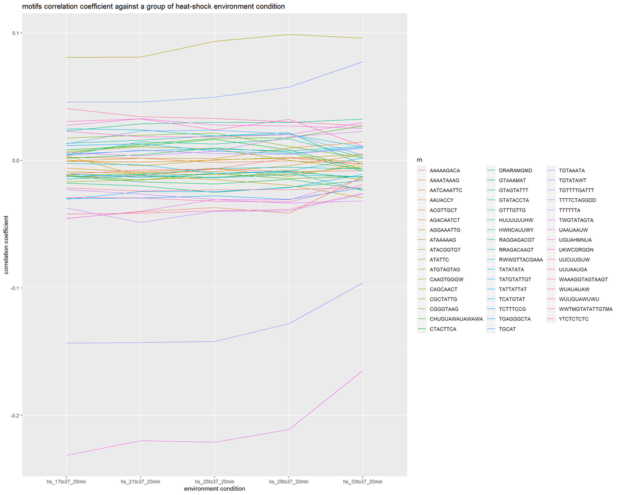

### Plot the four motifs with significant magnitude of correlation coefficient

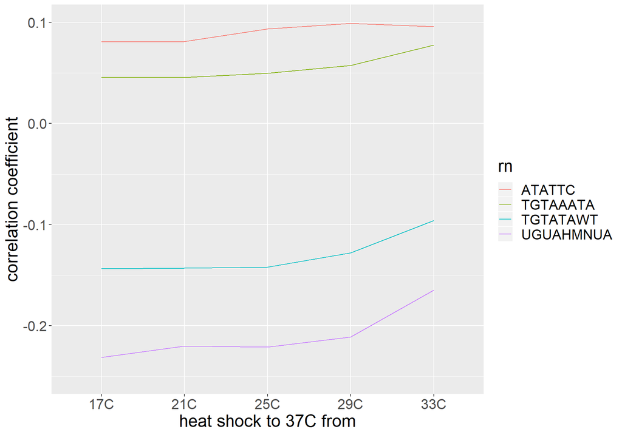

### Plot the distribution of the motifs with high coefficient

it is not hard to see the linear relation between these motifs and expression level

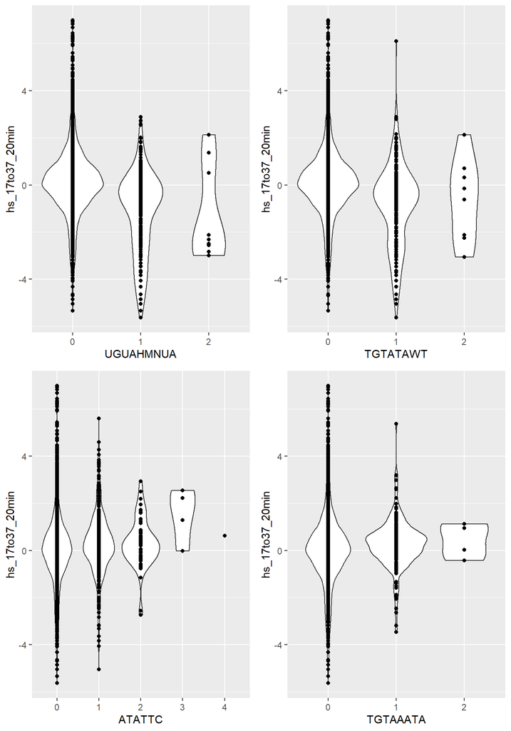

### Compare the frequency data between two similar motifs

Another point is that `TGTATAWT` is very likely to be a subset of `UGUAHMNUA`. The only difference between them is the A ending of the second motif. After comparing the frequency of them in each gene we could probably say that `UGUAHMNUA` and `TGTATAWT` are two distinguished sequence motifs since there are 228 genes contain more `UGUAHMNUA` than `TGTATAWT` and 155 genes contain more `TGTATAWT` than `UGUAHMNUA`.

```r
# the number of genes contain more UGUAHMNUA than TGTATAWT:
sum((fullTable_Gasch$UGUAHMNUA - fullTable_Gasch$TGTATAWT)>0)
```

```
## [1] 228
```

```r
# the number of genes contain more TGTATAWT than UGUAHMNUA:
sum((fullTable_Gasch$UGUAHMNUA - fullTable_Gasch$TGTATAWT)<0)
```

```
## [1] 155
```

```r
# the number of genes contain UGUAHMNUA
sum(fullTable_Gasch$UGUAHMNUA>0)
```

```
## [1] 336
```

```r
# the number of genes contain TGTATAWT
sum(fullTable_Gasch$TGTATAWT>0)
```

```
## [1] 262
```

# Carry out linear regression on two set of expression data

Building a linear model and check the coefficient could be another way to investigate the relationship between motifs and environment condition. In this case, we apply all the motifs with frequency larger than 0 to predict the change of expression level. We expect the 4 motifs with a high correlation coefficient are given relatively high weight in the model since they have shown a high linear dependency against expression level in the previous analysis.

### Train linear model on “Heat Shock from 17°C to 37°C” and “Heat Shock from 25°C to 37°C” with 50 motifs as feature values.

### Summary of the linear model training from “Heat Shock from 17°C to 37°C”

Overall, there is not significant problem with this linear model.

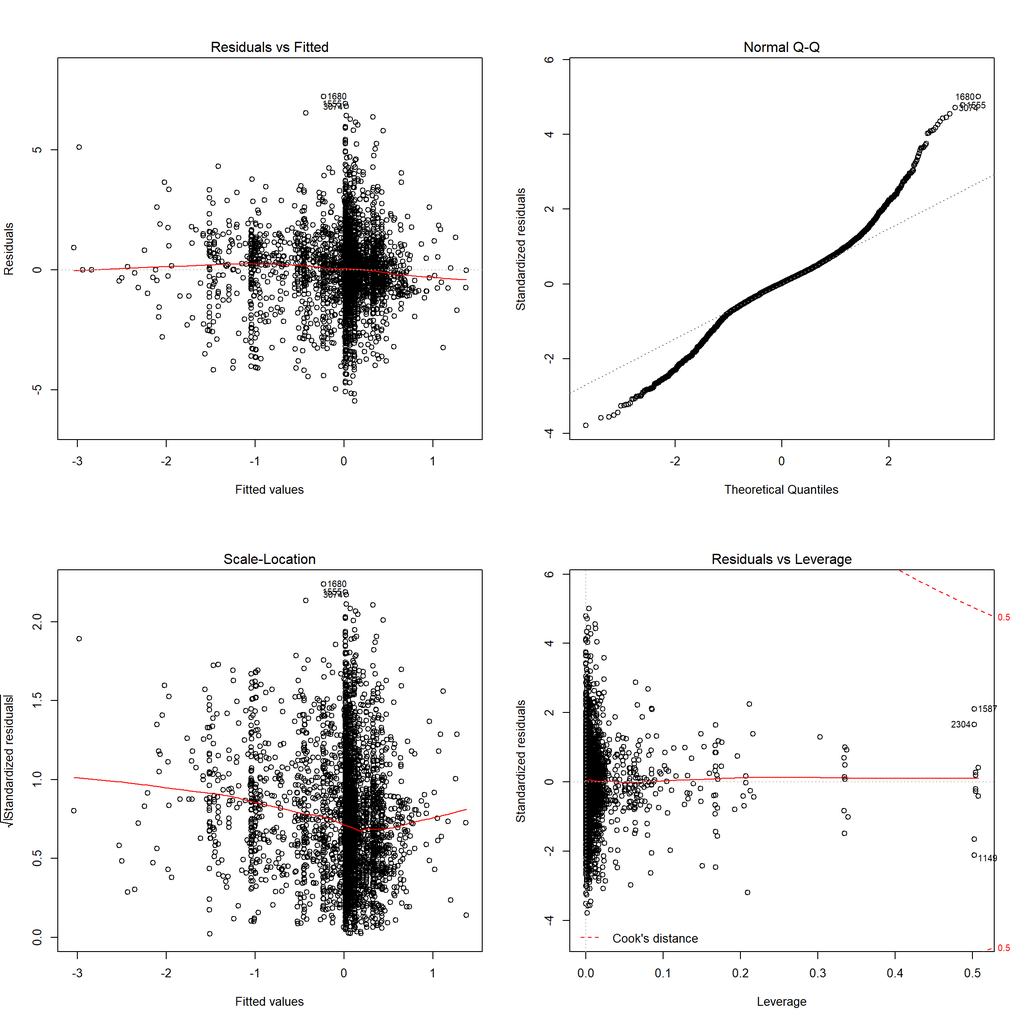

```
## [1] 2.063042
```

### Summary of the linear model training from “Heat Shock from 25°C to 37°C”

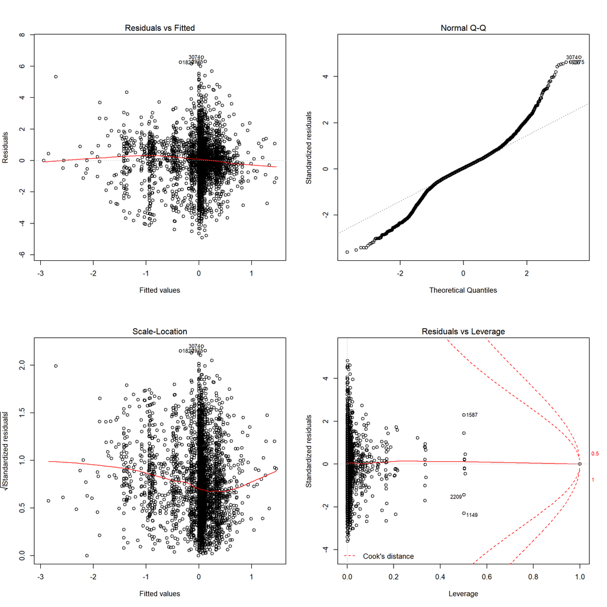

```
## [1] 1.832769
```

### Coefficient of the linear model training from “Heat Shock from 17°C to 37°C”

The error bar shows the 95% confidence interval.

all of the 4 motifs - `UGUAHMNUA`, `ATATTC`, `TGTATAWT`, and `TGTAAATA` gain a high coefficient and relatively low standard error as we expected. However, there are many other motifs that have a relatively high coefficient (but high standard error as well) in the model.

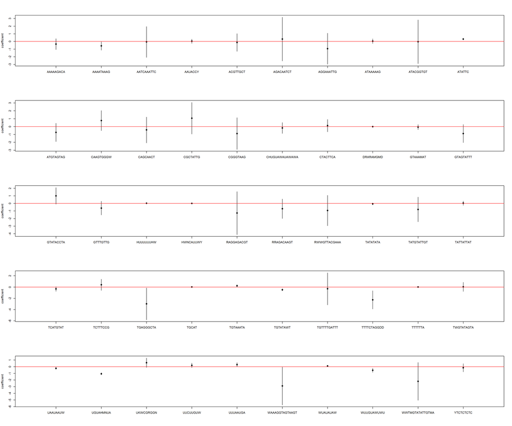

### Coefficient of the linear model training from “Heat Shock from 25°C to 37°C”

the second linear model shows a very similar coefficient as the previous one.

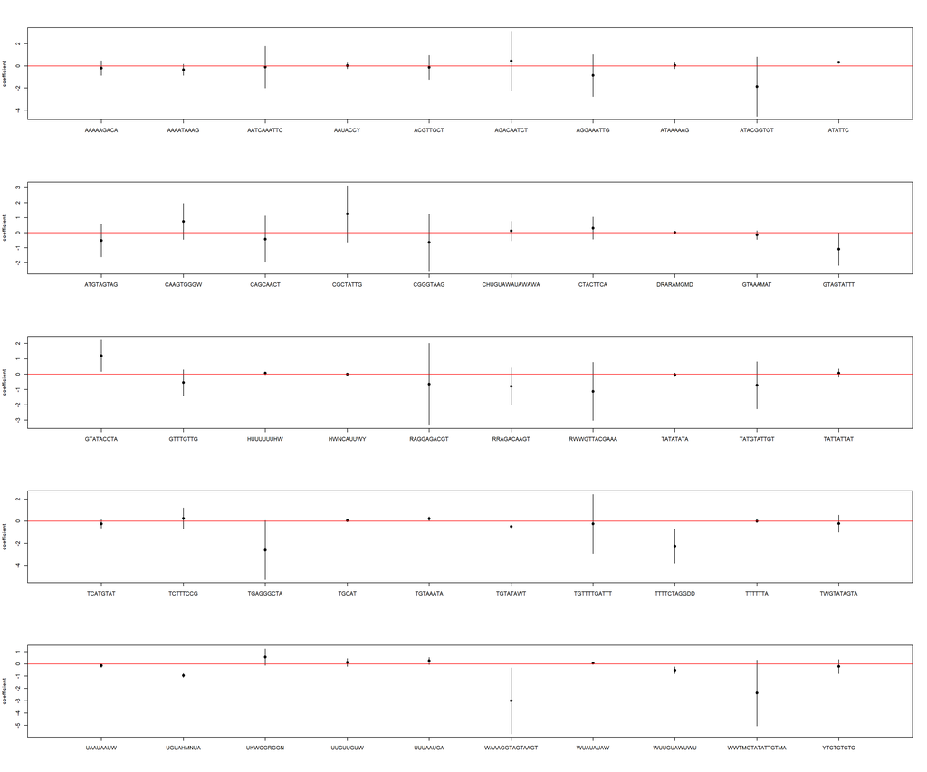

### Plot distribution of the motifs with unexpected high coefficient

The motifs with an unexpected high coefficient and high stadard error are mainly the motifs with low frequency.

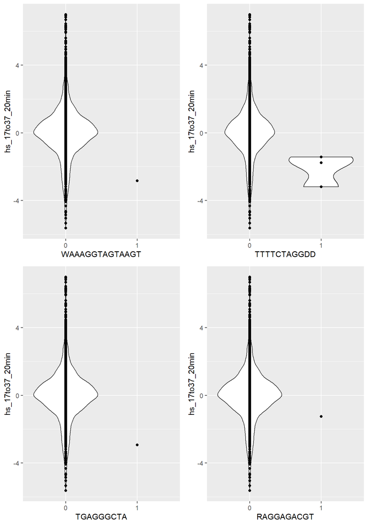

```r
lm_17to37
```

```
##
## Call:
## lm(formula = formula_lm_17to37, data = fullTable_Gasch)
##
## Coefficients:
##     (Intercept)           ATATTC            TGCAT         TGTAAATA
##        0.016377         0.309707         0.008127         0.233532
##         TTTTTTA   CHUGUAWAUAWAWA        UGUAHMNUA       WUUGUAWUWU
##        0.020011        -0.171384        -1.060605        -0.541327
##        UAAUAAUW         WUAUAUAW        HWNCAUUWY        DRARAMGMD
##       -0.252700         0.100027         0.003950        -0.000782
##         AAUACCY        UKWCGRGGN         UUUAAUGA         UUCUUGUW
##        0.038569         0.592011         0.309703         0.198358
##        TATATATA        ATGTAGTAG        GTAGTATTT         GTAAAMAT
##       -0.053312        -0.733379        -0.877592        -0.067003
##       GTATACCTA       RAGGAGACGT        TATTATTAT      TGTTTTGATTT
##        1.001231        -1.274504         0.036566        -0.307867
##       AGGAAATTG         CGGGTAAG         ATAAAAAG        AAAAAGACA
##       -0.936605        -0.877498         0.046453        -0.330460
##       CAAGTGGGW         CTACTTCA        TGAGGGCTA        YTCTCTCTC
##        0.770104         0.127857        -2.964504        -0.152829
##       AGACAATCT         TGTATAWT       TATGTATTGT         CGCTATTG
##        0.314718        -0.469664        -0.787775         1.066868
##        TCATGTAT         CAGCAACT       AATCAAATTC        ATACGGTGT
##       -0.333340        -0.425050        -0.059964        -0.029682
##        ACGTTGCT         TCTTTCCG      TTTTCTAGGDD         GTTTGTTG
##       -0.128739         0.410827        -2.266418        -0.613505
##      RRAGACAAGT  WWTMGTATATTGTMA       TWGTATAGTA        AAAATAAAG
##       -0.702845        -2.201510         0.042279        -0.573043
##    RWWGTTACGAAA   WAAAGGTAGTAAGT        HUUUUUUHW
##       -0.936494        -2.902048         0.032518
```

# Carry out linear regression with high-frequency motif (>20)

### Remove low-frequency motifs to eliminate unexpected influence.

We are not confident enough to tell whether a low-frequency motif depends linearly on the heat-shock related environment condition. Therefore, we temporarily remove them and carry out linear regression again to see if we may find any other linearly related motifs.

### Summary of the linear model training from “Heat Shock from 17°C to 37°C”

Similar to the previous one

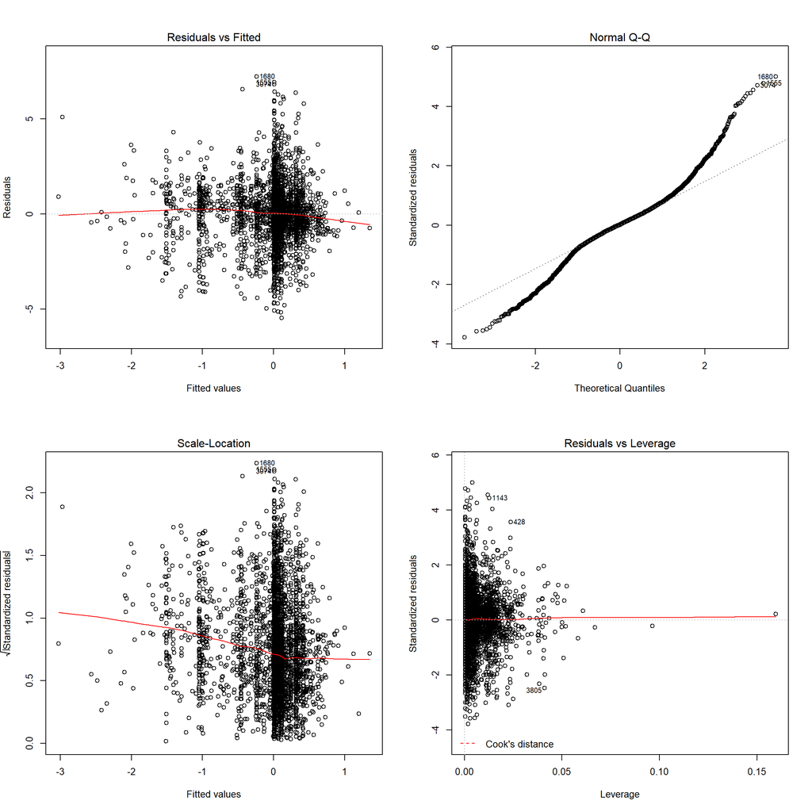

```
## [1] 2.082218
```

### Summary of the linear model training from “Heat Shock from 25°C to 37°C”

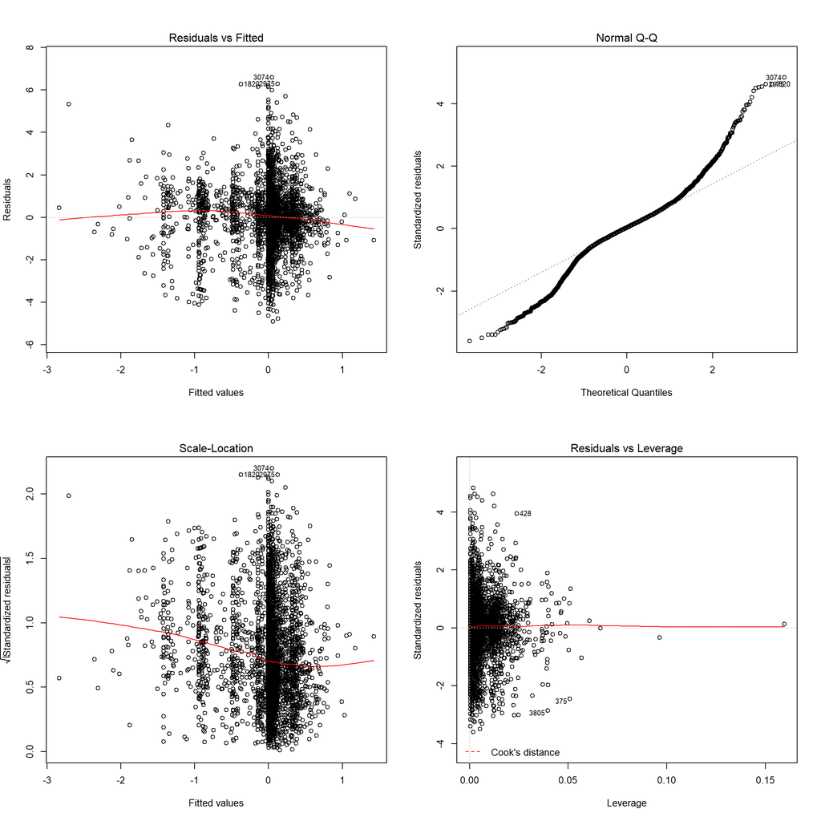

```
## [1] 1.852871
```

### Coefficient of the linear model training from “Heat Shock from 17°C to 37°C”

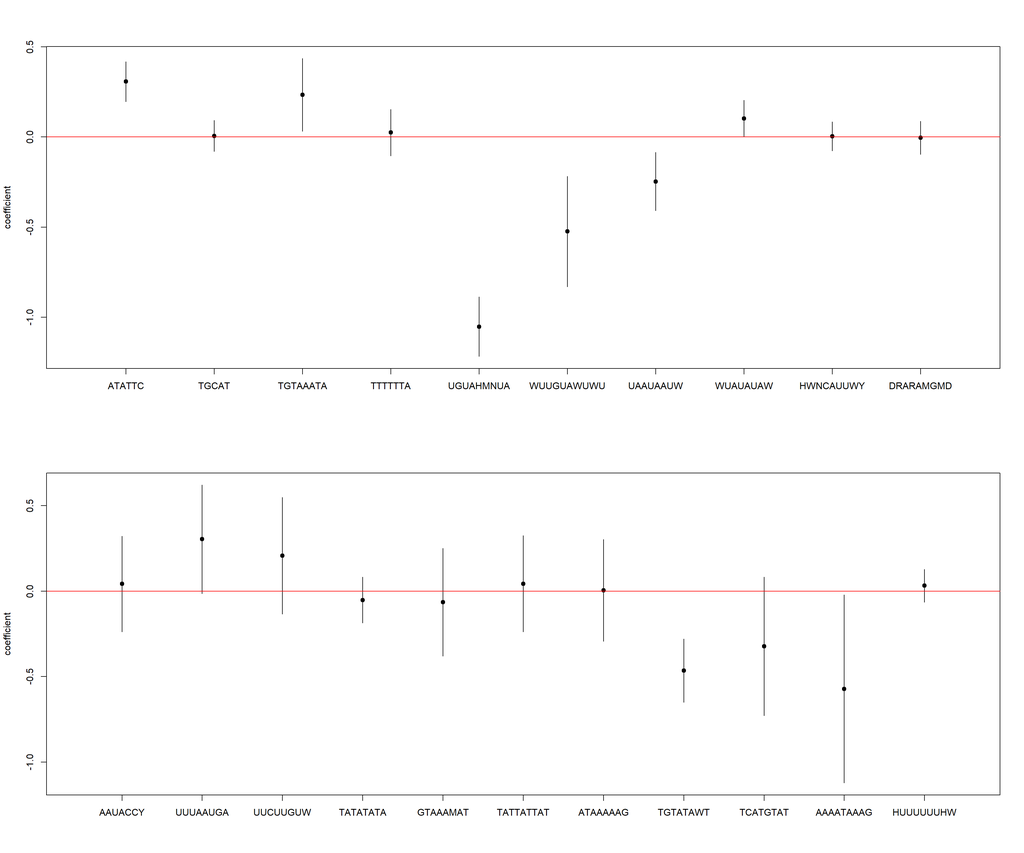

### Coefficient of the linear model training from “Heat Shock from 25°C to 37°C”

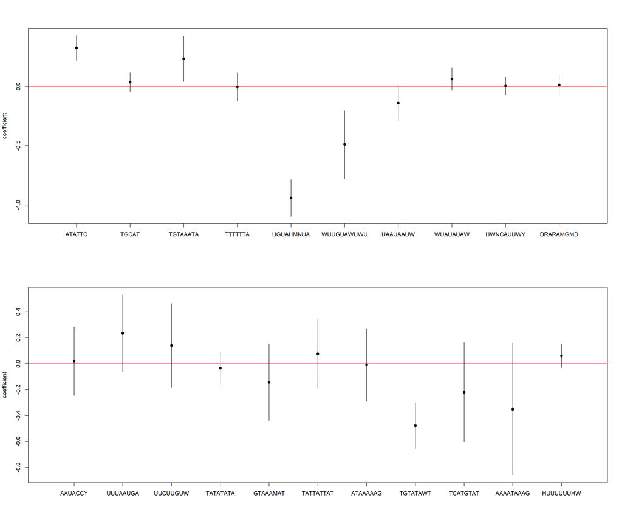

### checking the coefficient, Std.Error, and t value of the motifs with high coefficient in linear model training from “Heat Shock from 17°C to 37°C”

`Estimate` shows the coefficient or weight gains by the responding features in this linear model. `Std.Error` is the standard error of the `estimate` value, which, can be used to calculate the Confidence interval. For example, the 95% confident interval could be obtained from Estimate +- 1.96*Std.Error. `t value` is calculated from the estimates divided by their standard errors. To make the best use of this value, we need to look up the table of t distribution to learn the reject boundary. In this case, we could simply say the larger the magnitude of the t-value is, the less likely that the coefficient is 0. `Pr(>\|t\|)` is the p-value which is the probability of achieving a |t| as large as or larger than the observed absolute t value if the null hypothesis (estimate = 0) was true. In short, it is the probability that there is no relationship between that feature and the predicted value.

motifs with relatively low p-value are listed below:

| Motif | Estimate | Std.Error | t value | Pr(>\|t\|) |
| --- | --- | --- | --- | --- |
| UGUAHMNUA | -1.052 | 0.084 | -12.445 | <2e-16 |
| ATATTC | 0.308 | 0.057 | 5.429 | 5.98e-08 |
| TGTATAWT | -0.465 | 0.095 | -4.898 | 1.00e-06 |
| WUUGUAWUWU | -0.524 | 0.156 | -3.354 | 0.0008 |
| UAAUAAUW | -0.247 | 0.083 | -2.991 | 0.0028 |
| TGTAAATA | 0.234 | 0.103 | 2.263 | 0.0237 |
| AAAATAAAG | -0.572 | 0.281 | -2.035 | 0.0420 |
| UUUAAUGA | 0.304 | 0.162 | 1.874 | 0.0610 |
| TCATGTAT | -0.324 | 0.207 | -1.564 | 0.1179 |

None of the 5 additional motifs has been mentioned in Abhi’s report. More tests should be carried out on these motifs for a more general conclusion.

Although the influence seems to be very slight, these motifs do have a linear relationship with expression level

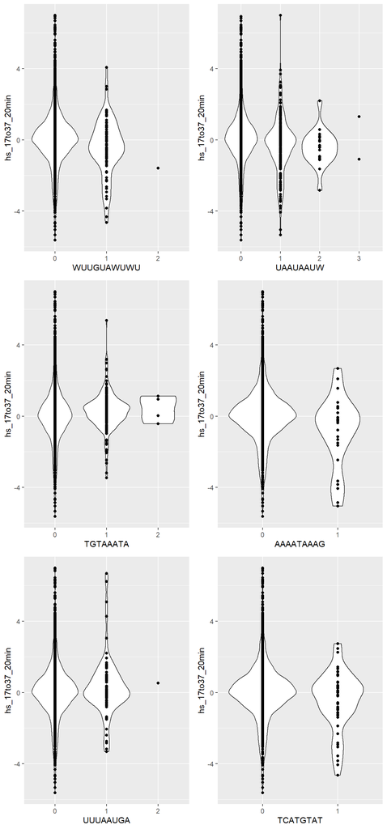

# Summary

we have analyzed 4284 / 6152 of genes, 5/173 of heat-shock-relevant environment conditions provided by Gasch’s data and 50 motifs from 69 published motifs (65 experimented motifs and 4 Cheng’s motifs). More than half of the motifs has a relatively low frequency. By investigating the corresponding correlation coefficient and carrying out linear regression, we found 4 strong linear-related motifs and 5 weak linear-related motifs. Thus, Only a small fraction of motifs responds to heat-shock related environment stress.

As Gasch’s study mentioned:

> the ESR (environment stress respond) is not initiated in response to all environmental changes

> Unlike the response to a 25°C to 37°C heat shock, which elicited massive and transient changes in ESR expression, the transition from 37°C to 25°C resulted in a simple rapid transition to the gene expression program characteristic of steady-state growth at 25°C, with essentially no transient features.

> The ESR is initiated not only by conditions known to threaten cellular viability, but also by small environmental changes that do not detectably impair viability and growth.

Only part of the environment changes initiate ESR. heat-shock from 25°C to 37°C is one of them. Gene expression levels under a non-ESR-initiated environmental change may probably be influenced by different motifs. Maybe it’s worth to look into another group of environmental conditions?

# Compare the correlation between heat-shock and cool down

### Picking a group of heat-shock related environment condition

```r
names_temperature_condition = vector(mode="character", length=5)
names_temperature_condition[1] = "hs_15min_hs-1"
names_temperature_condition[2] = "hs_30min_hs-1"
names_temperature_condition[3] = "hs_40min_hs-1"
names_temperature_condition[4] = "hs_60min_hs-1"
names_temperature_condition[5] = "hs_80min_hs-1"
```

```r
summary(fullTable_Gasch[names_temperature_condition])
```

```
##  hs_15min_hs-1     hs_30min_hs-1     hs_40min_hs-1     hs_60min_hs-1
##  Min.   :-6.6400   Min.   :-6.6400   Min.   :-5.0600   Min.   :-3.840
##  1st Qu.:-0.7900   1st Qu.:-0.7400   1st Qu.:-0.6400   1st Qu.:-0.360
##  Median :-0.1000   Median :-0.1200   Median :-0.1500   Median :-0.030
##  Mean   :-0.1553   Mean   :-0.1247   Mean   :-0.1435   Mean   :-0.028
##  3rd Qu.: 0.5225   3rd Qu.: 0.5000   3rd Qu.: 0.3200   3rd Qu.: 0.260
##  Max.   : 7.2200   Max.   : 6.5900   Max.   : 4.8700   Max.   : 3.660
##  NA's   :292       NA's   :384       NA's   :709       NA's   :361
##  hs_80min_hs-1
##  Min.   :-3.6400
##  1st Qu.:-0.3500
##  Median :-0.0300
##  Mean   :-0.0163
##  3rd Qu.: 0.2900
##  Max.   : 3.4600
##  NA's   :776
```

### Calculate the correlation coefficient

At this step, we get a data frame that each row represent the correlation coefficients of a motif under these environmental conditions

a peek of the dataset:

```r
head(motif_overview)
```

```
##            hs_15min_hs-1 hs_30min_hs-1 hs_40min_hs-1 hs_60min_hs-1
## ATATTC        0.09045791   0.079236945    0.06931051    0.04029746
## TGCAT         0.01978816   0.011690574   -0.00199235   -0.01465319
## TGTAAATA      0.06410357   0.081523981    0.06147658    0.04333856
## TTTTTTA       0.03229043   0.003384501    0.01945574   -0.02579855
## UGUAHMNUA    -0.26339738  -0.234508496   -0.20609492   -0.18247887
## WUUGUAWUWU   -0.03455516  -0.040697757   -0.02864093   -0.05406717
##            hs_80min_hs-1       R_mean
## ATATTC      0.0356548192  0.062991527
## TGCAT      -0.0006008341  0.002846472
## TGTAAATA    0.0308662971  0.056261796
## TTTTTTA    -0.0480460649 -0.003742787
## UGUAHMNUA  -0.1574629274 -0.208788520
## WUUGUAWUWU -0.0420756404 -0.040007330
```

```r
summary(motif_overview)
```

```
##  hs_15min_hs-1       hs_30min_hs-1       hs_40min_hs-1
##  Min.   :-0.263397   Min.   :-0.234509   Min.   :-0.206095
##  1st Qu.:-0.032892   1st Qu.:-0.026743   1st Qu.:-0.028641
##  Median : 0.019788   Median : 0.003384   Median : 0.009195
##  Mean   :-0.005587   Mean   :-0.007143   Mean   :-0.007398
##  3rd Qu.: 0.036135   3rd Qu.: 0.032109   3rd Qu.: 0.023978
##  Max.   : 0.090458   Max.   : 0.081524   Max.   : 0.069311
##  hs_60min_hs-1      hs_80min_hs-1           R_mean
##  Min.   :-0.18248   Min.   :-0.157463   Min.   :-0.2087885
##  1st Qu.:-0.02714   1st Qu.:-0.037235   1st Qu.:-0.0249526
##  Median :-0.01460   Median :-0.005869   Median : 0.0006329
##  Mean   :-0.01794   Mean   :-0.012303   Mean   :-0.0100745
##  3rd Qu.: 0.01441   3rd Qu.: 0.018283   3rd Qu.: 0.0302319
##  Max.   : 0.04334   Max.   : 0.048850   Max.   : 0.0629915
```

### Plot coefficient of each motif against each heat-shock related environment condition

There are four motifs show a much higher correlation coefficient rather than the others, which, indicate the linear relationship between these motifs and expression level. One point worth mentioning is that all these motifs are also focused by Abhi where `TGTATAWT` is explained to be positively associated with RNA stability and the rest three of them are explained to be negatively associated with the RNA stability. However, Abhi is not quite confident with the conclusion of `UGUAHMNUA` as the negative relationship can only be derived from Chan’s data but not Sun’s data.

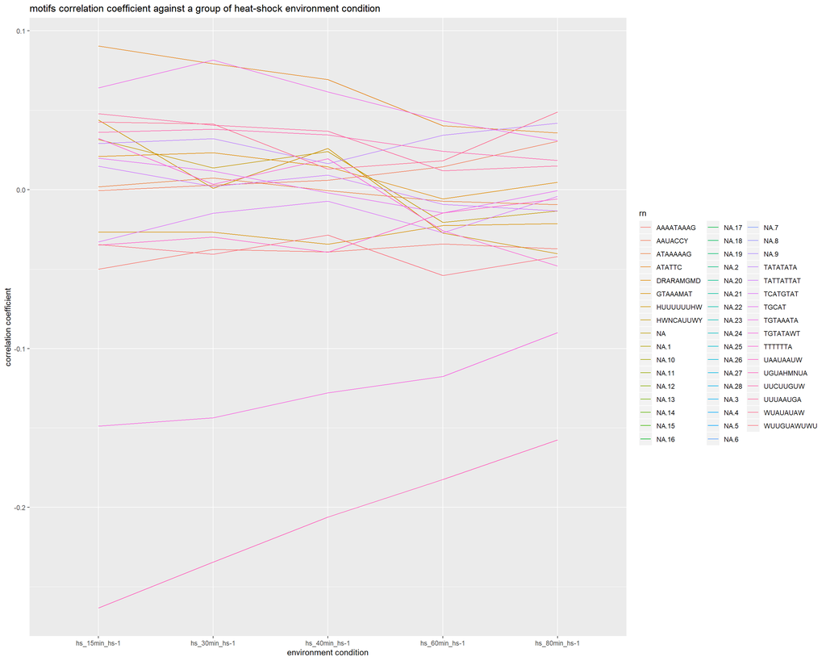

### Plot the four motifs with significant magnitude of correlation coefficient

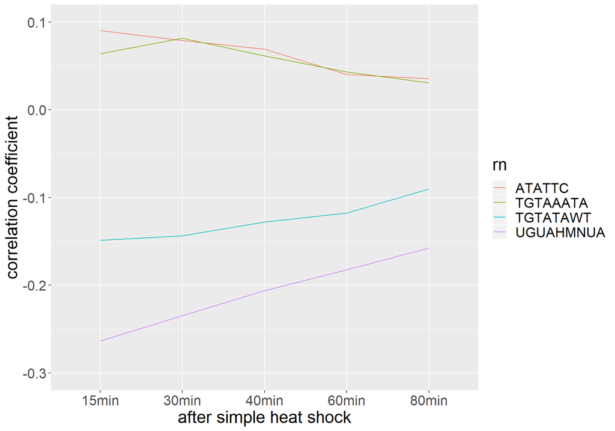

# Explore the correlation under combination stress of heat shock

### Calculate correlation coefficient and plot them

> To measure steady-state expression at each temperature, RNA collected from cells grown continuously at each temperature was also compared directly to RNA from cells grown at 33°C.

```r
# pick a group of temperature condition
names_temperature_condition = vector(mode="character", length=3)
names_temperature_condition[1] = "29C(1M_sorbitol)~33C(1M_sorbitol)_05min"
names_temperature_condition[2] = "29C(1M_sorbitol)~33C(1M_sorbitol)_15min"
names_temperature_condition[3] = "29C(1M_sorbitol)~33C(1M_sorbitol)_30min"

# compute correlation coefficient
motif_overview_steady_temperature <- as.data.frame(
  cor(fullTable_Gasch[names_motifs_valid],fullTable_Gasch[names_temperature_condition], use = "na.or.complete"))
```

### Plot coefficient against each motif

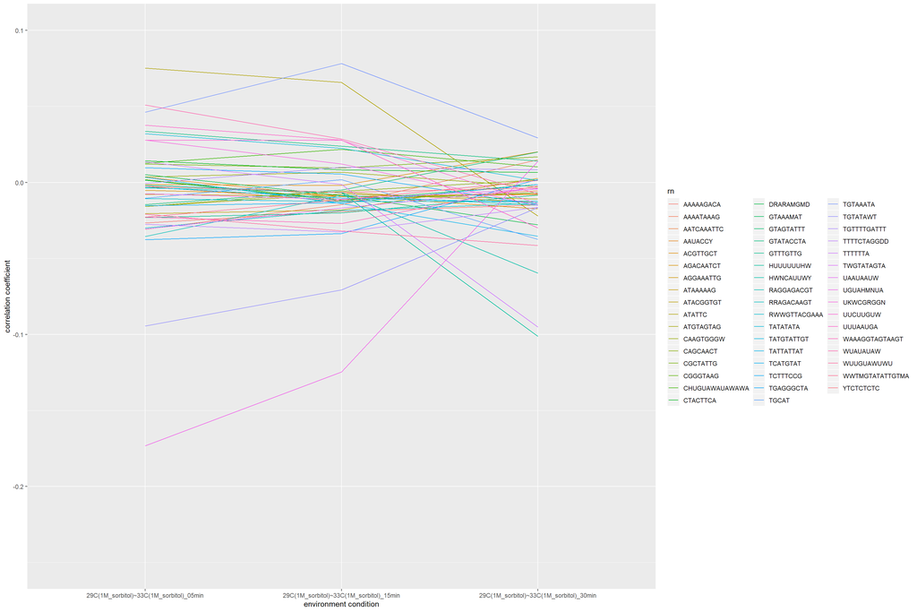

### correlation coefficient of the 4 strong linear-related motifs

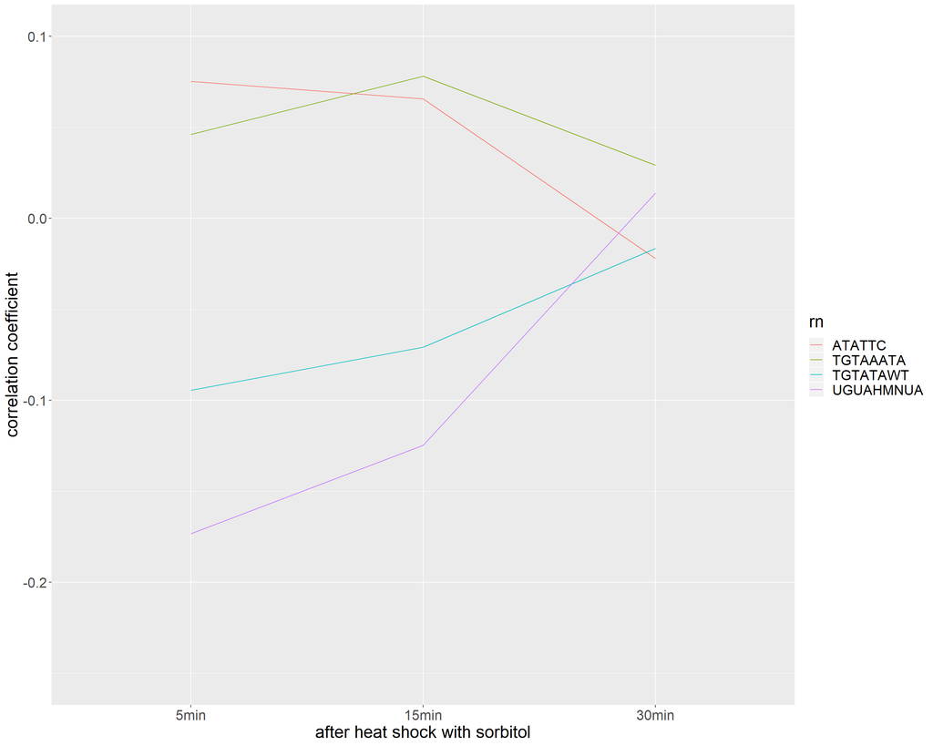

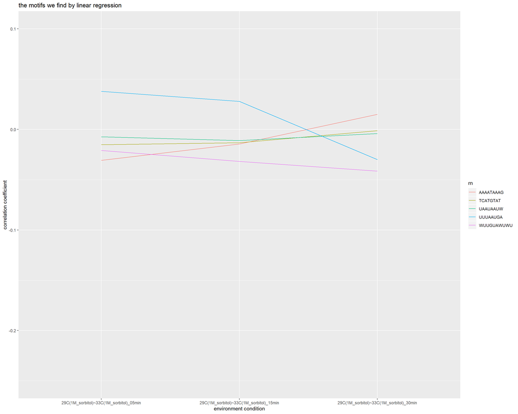

### other motifs with interesting curves

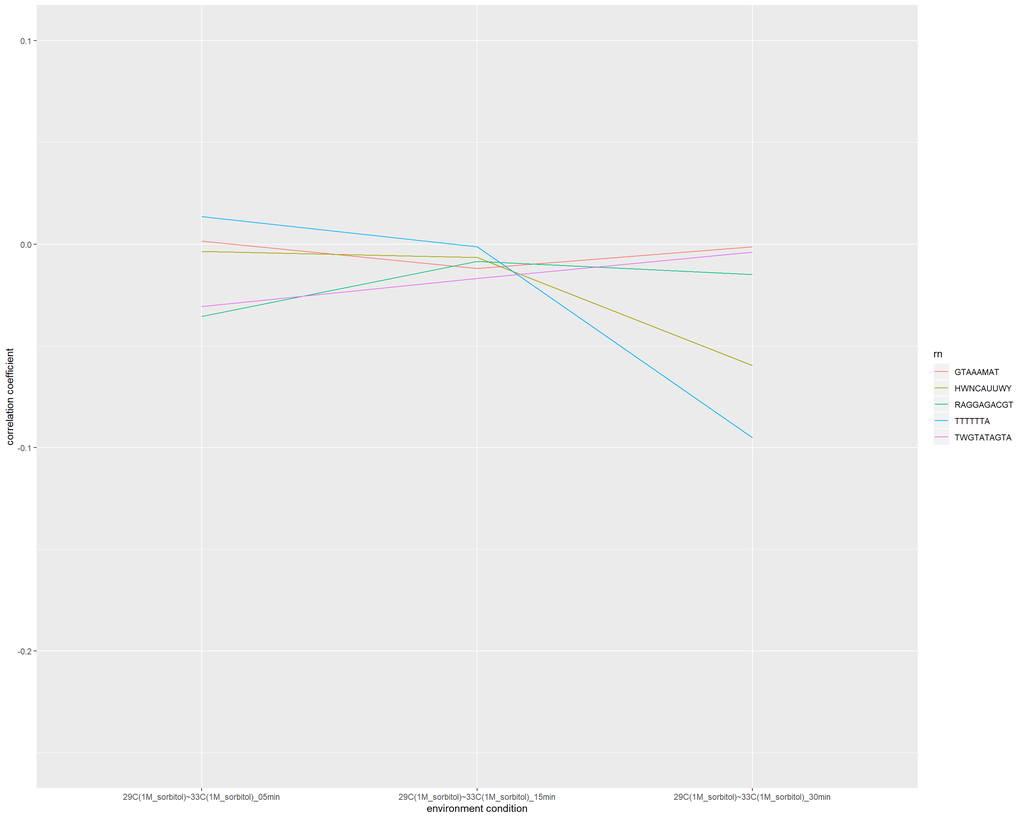

# Explore the correlation between motifs frequency and expression level under a environment change that won’t cause ESR.

### Picking a group of heat-shock reversed environment condition

```r
names_temperature_condition = vector(mode="character", length=5)
names_temperature_condition[1] = "hs_37to25_15min"
names_temperature_condition[2] = "hs_37to25_30min"
names_temperature_condition[3] = "hs_37to25_45min"
names_temperature_condition[4] = "hs_37to25_60min"
names_temperature_condition[5] = "hs_37to25_90min"
```

### Calculate the correlation coefficient

At this step, we get a data frame that each row represent the correlation coefficients of a motif under these environmental conditions

### Plot coefficient of each motif against each heat-shock related environment condition

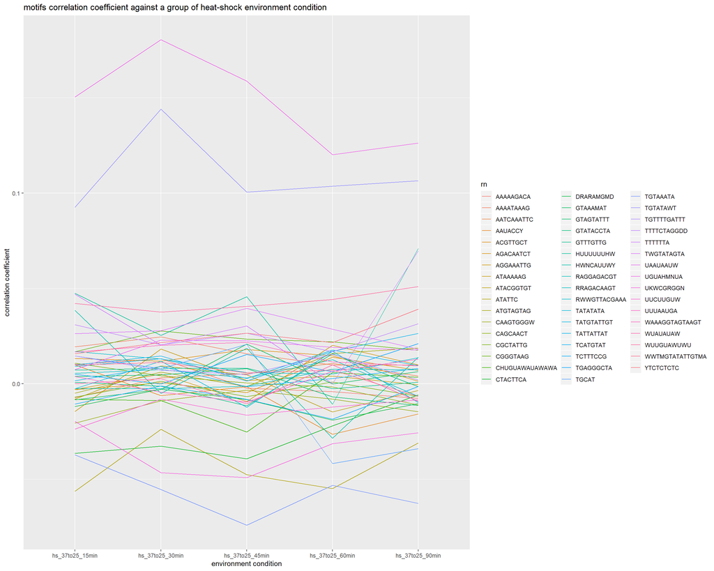

### Plot the four motifs with significant magnitude of correlation coefficient

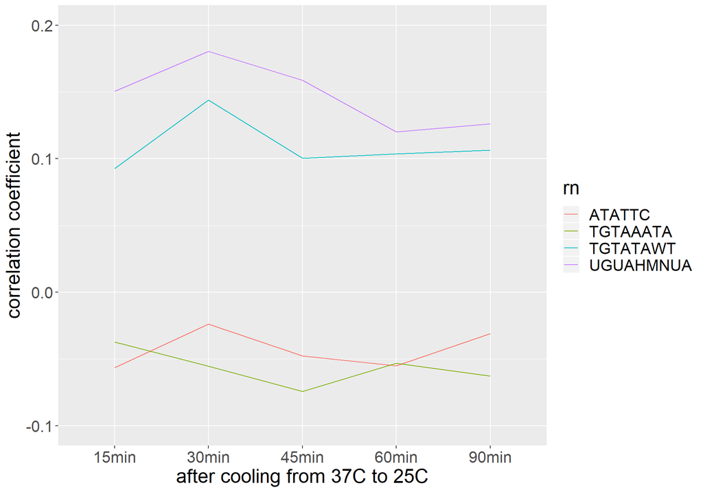